# Red Wine EDA by Bhargava

> **Whats a Red Wine?**: Red wine is a type of wine made from dark-colored (black) grape varieties. The actual color of the wine can range from intense violet, typical of young wines, through to brick red for mature wines and brown for older red wines. The red color comes from anthocyan pigments (also called anthocyanins) present in the skin of the grape

> **Introduction to Dataset**: The dataset is a tidy csv file containing 1599 observations and have 13 variables associated to them. I will perform Exploratory Data Analysis (EDA) on a data set which contains red wines with variables on the chemical properties of the wine. I will use visual methods (univariate, bivariate and multivariate plots) to summarise the main charecteristics of the data set. Main goal here is to find what factors contribute to quality of a red wine i.e “What makes a rating 8 wine different from a rating 3”

#### Structure Of The Dataset

```
## 'data.frame':    1599 obs. of  13 variables:
##  $ X                   : int  1 2 3 4 5 6 7 8 9 10 ...
##  $ fixed.acidity       : num  7.4 7.8 7.8 11.2 7.4 7.4 7.9 7.3 7.8 7.5 ...
##  $ volatile.acidity    : num  0.7 0.88 0.76 0.28 0.7 0.66 0.6 0.65 0.58 0.5 ...
##  $ citric.acid         : num  0 0 0.04 0.56 0 0 0.06 0 0.02 0.36 ...
##  $ residual.sugar      : num  1.9 2.6 2.3 1.9 1.9 1.8 1.6 1.2 2 6.1 ...
##  $ chlorides           : num  0.076 0.098 0.092 0.075 0.076 0.075 0.069 0.065 0.073 0.071 ...
##  $ free.sulfur.dioxide : num  11 25 15 17 11 13 15 15 9 17 ...
##  $ total.sulfur.dioxide: num  34 67 54 60 34 40 59 21 18 102 ...
##  $ density             : num  0.998 0.997 0.997 0.998 0.998 ...
##  $ pH                  : num  3.51 3.2 3.26 3.16 3.51 3.51 3.3 3.39 3.36 3.35 ...
##  $ sulphates           : num  0.56 0.68 0.65 0.58 0.56 0.56 0.46 0.47 0.57 0.8 ...
##  $ alcohol             : num  9.4 9.8 9.8 9.8 9.4 9.4 9.4 10 9.5 10.5 ...
##  $ quality             : int  5 5 5 6 5 5 5 7 7 5 ...
```

#### Summary of Dataset

```
##        X          fixed.acidity   volatile.acidity  citric.acid
##  Min.   :   1.0   Min.   : 4.60   Min.   :0.1200   Min.   :0.000
##  1st Qu.: 400.5   1st Qu.: 7.10   1st Qu.:0.3900   1st Qu.:0.090
##  Median : 800.0   Median : 7.90   Median :0.5200   Median :0.260
##  Mean   : 800.0   Mean   : 8.32   Mean   :0.5278   Mean   :0.271
##  3rd Qu.:1199.5   3rd Qu.: 9.20   3rd Qu.:0.6400   3rd Qu.:0.420
##  Max.   :1599.0   Max.   :15.90   Max.   :1.5800   Max.   :1.000
##  residual.sugar     chlorides       free.sulfur.dioxide
##  Min.   : 0.900   Min.   :0.01200   Min.   : 1.00
##  1st Qu.: 1.900   1st Qu.:0.07000   1st Qu.: 7.00
##  Median : 2.200   Median :0.07900   Median :14.00
##  Mean   : 2.539   Mean   :0.08747   Mean   :15.87
##  3rd Qu.: 2.600   3rd Qu.:0.09000   3rd Qu.:21.00
##  Max.   :15.500   Max.   :0.61100   Max.   :72.00
##  total.sulfur.dioxide    density             pH          sulphates
##  Min.   :  6.00       Min.   :0.9901   Min.   :2.740   Min.   :0.3300
##  1st Qu.: 22.00       1st Qu.:0.9956   1st Qu.:3.210   1st Qu.:0.5500
##  Median : 38.00       Median :0.9968   Median :3.310   Median :0.6200
##  Mean   : 46.47       Mean   :0.9967   Mean   :3.311   Mean   :0.6581
##  3rd Qu.: 62.00       3rd Qu.:0.9978   3rd Qu.:3.400   3rd Qu.:0.7300
##  Max.   :289.00       Max.   :1.0037   Max.   :4.010   Max.   :2.0000
##     alcohol         quality
##  Min.   : 8.40   Min.   :3.000
##  1st Qu.: 9.50   1st Qu.:5.000
##  Median :10.20   Median :6.000
##  Mean   :10.42   Mean   :5.636
##  3rd Qu.:11.10   3rd Qu.:6.000
##  Max.   :14.90   Max.   :8.000
```

> **Closer look at quality**:

```
##
##   3   4   5   6   7   8
##  10  53 681 638 199  18
```

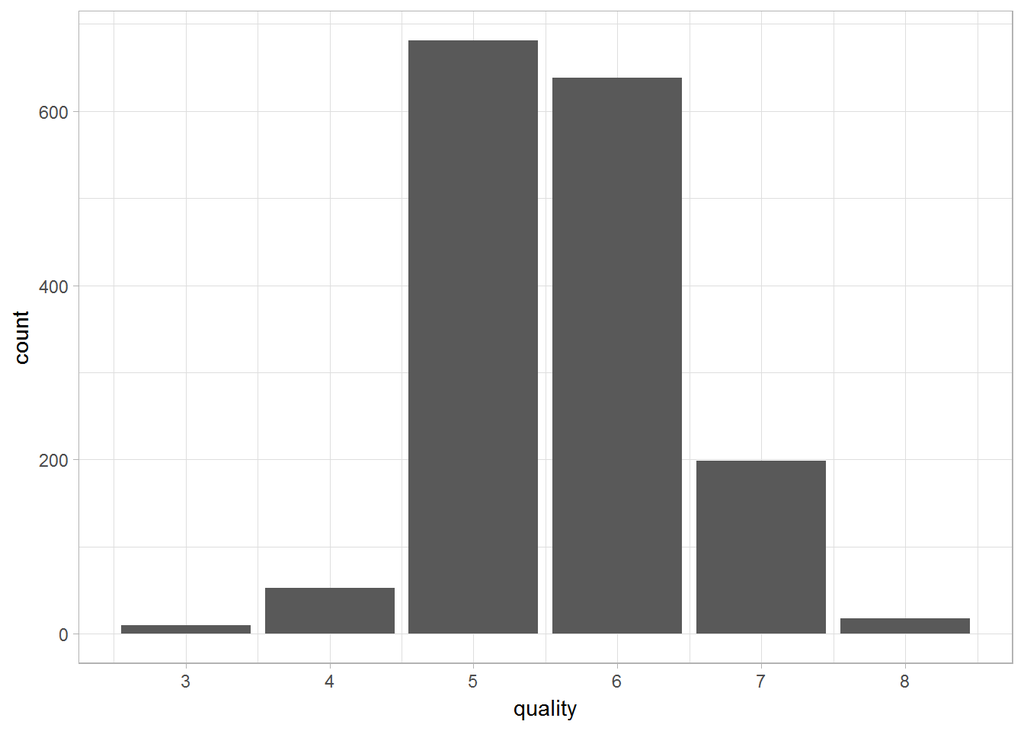

```
##    Min. 1st Qu.  Median    Mean 3rd Qu.    Max.
##   3.000   5.000   6.000   5.636   6.000   8.000
```

```
## 85%
##   6
```

We can see the the 3 is the minimum rating given to quality and 8 is the maximum. The distribution is normal with 85% data points below or 6. So I have created a variable called ‘rating’ based on variable quality

> **8 to 7 are rated A,**

> **6 to 5 are rated B,**

> **3 to 4 are rated C**

```
##    C    B    A
##   63 1319  217
```

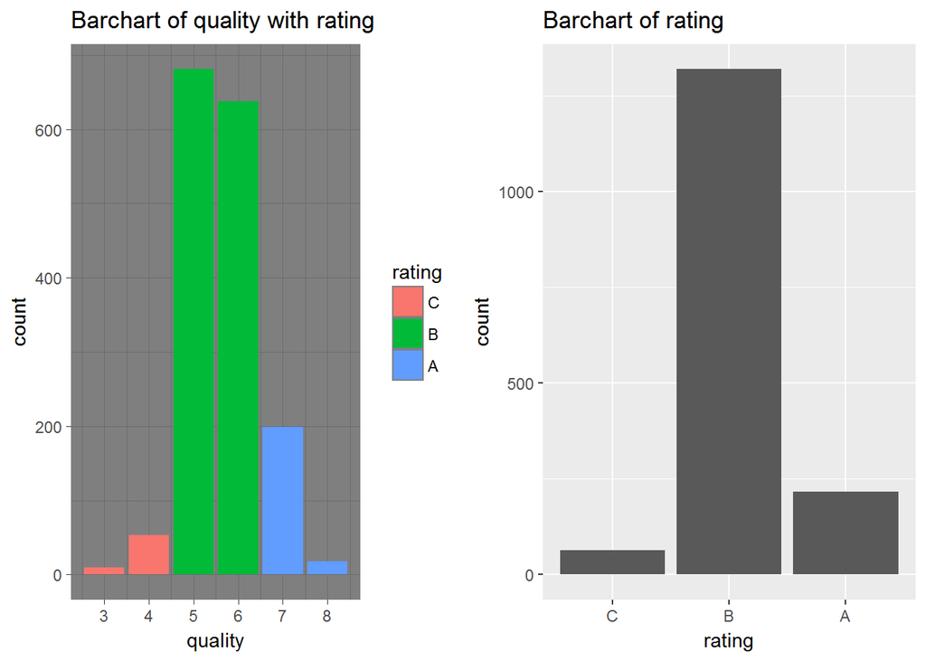

# Univariate Plots Section

#### Residual sugar (g / dm^3)

residual sugar: the amount of sugar remaining after fermentation stops, it’s rare to find wines with less than 1 gram/liter and wines with greater than 45 grams/liter are considered sweet

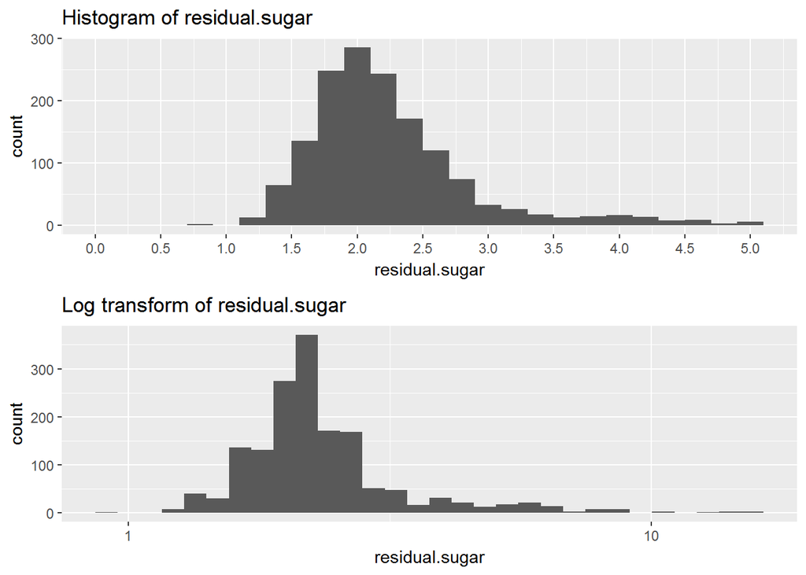

```
##    Min. 1st Qu.  Median    Mean 3rd Qu.    Max.
##   0.900   1.900   2.200   2.539   2.600  15.500
```

It a normal distribution with a long tail,I have removed outliers(top 5%) from the graph .The second graph is the log transformation of residual sugar The mean value is 2.53 and max goes all the way up to 15.50

#### Alcohol (% by volume)

Alcohol (% by volume): the percent alcohol content of the wine. Wine is an alcoholic breverage . I am hopin to see some trend in this data now and in my further observations

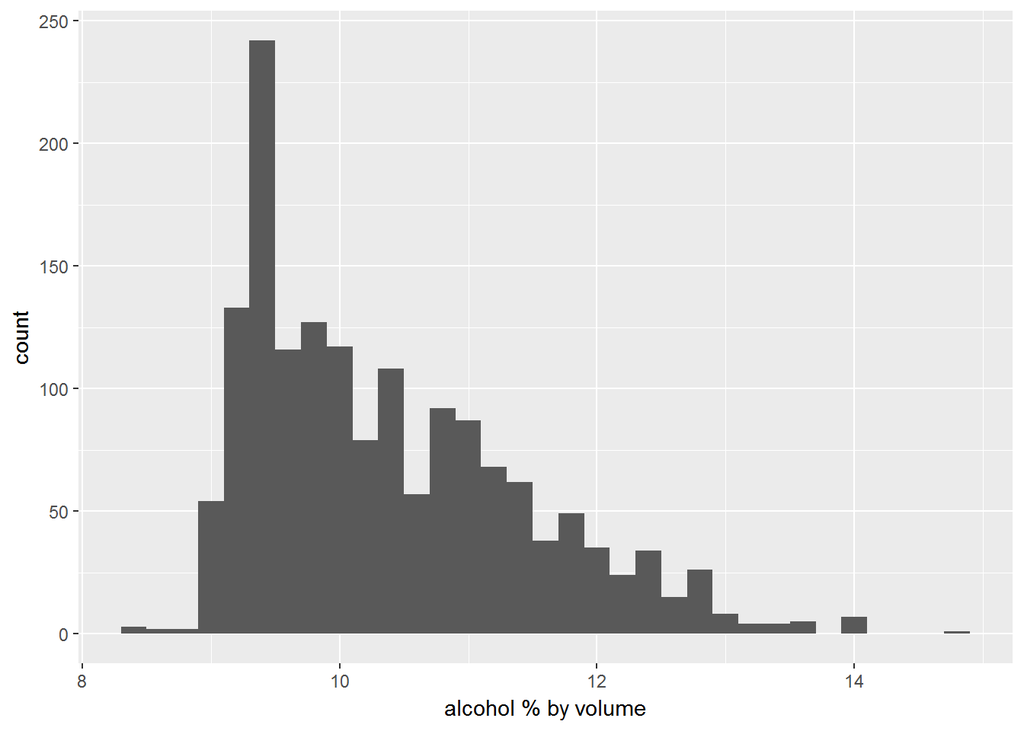

```
##    Min. 1st Qu.  Median    Mean 3rd Qu.    Max.
##    8.40    9.50   10.20   10.42   11.10   14.90
```

#### Fixed acidity (tartaric acid - g / dm^3)

fixed acidity: most acids involved with wine or fixed or nonvolatile (do not evaporate readily)

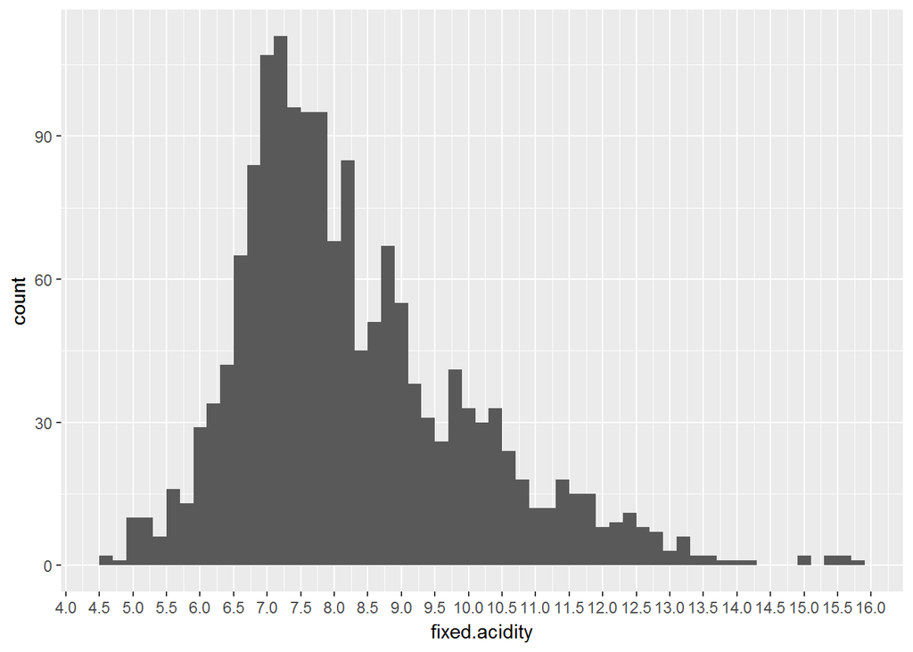

```
##    Min. 1st Qu.  Median    Mean 3rd Qu.    Max.
##    4.60    7.10    7.90    8.32    9.20   15.90
```

Its a normal distribution which peaks at 7 it has a mean of 8.32 and a maximum value of 15.90

#### Volatile acidity (acetic acid - g / dm^3)

volatile acidity: the amount of acetic acid in wine, which at too high of levels can lead to an unpleasant, vinegar taste

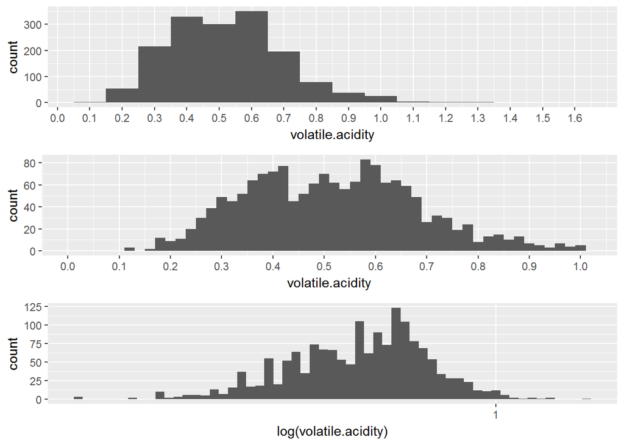

```
##    Min. 1st Qu.  Median    Mean 3rd Qu.    Max.
##  0.1200  0.3900  0.5200  0.5278  0.6400  1.5800
```

At bigger bin width the plot appears to have a long tail.But after reducing the binwidth to 0.02 and removing the outliers,the bimodal nature of the distribution appears which has two peaks at 0.4 and 0.6. In the third graph I have use log transformation to deal with the long tailed nature The mean of the distribution is at 0.52

#### pH

pH: describes how acidic or basic a wine is on a scale from 0 (very acidic) to 14 (very basic); most wines are between 3-4 on the pH scale

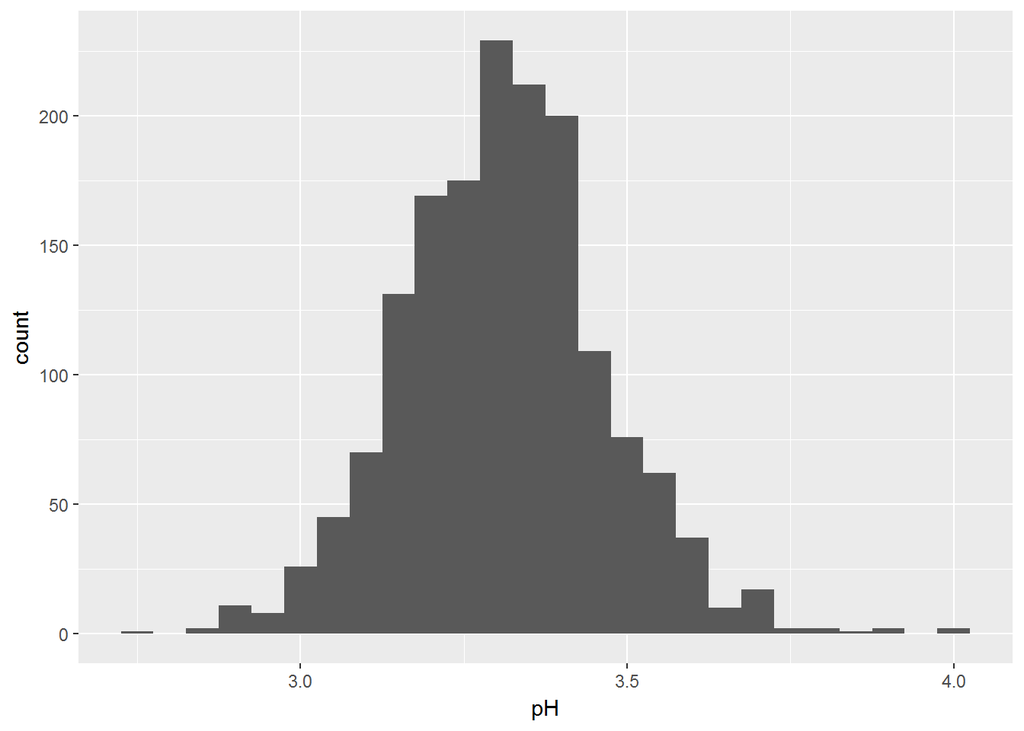

```
##    Min. 1st Qu.  Median    Mean 3rd Qu.    Max.
##   2.740   3.210   3.310   3.311   3.400   4.010
```

The distribution is normal with a little tailing . It has mean of 3.31 and maximum value of 4.01

#### Density (g / cm^3)

density: the density of wine is close to that of water depending on the percent alcohol and sugar content

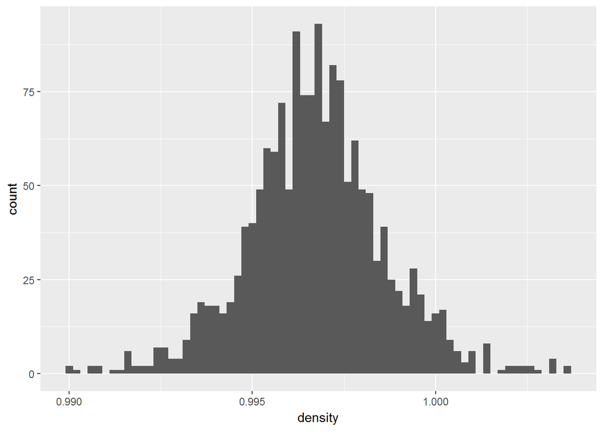

```
##    Min. 1st Qu.  Median    Mean 3rd Qu.    Max.
##  0.9901  0.9956  0.9968  0.9967  0.9978  1.0037
```

```
## [1] 0.001887334
```

The distribution is normal approaching to 1 which is density of water.The standard deviation is also very small 0.0018

#### Citric acid (g / dm^3)

citric acid: found in small quantities, citric acid can add ‘freshness’ and flavor to wines

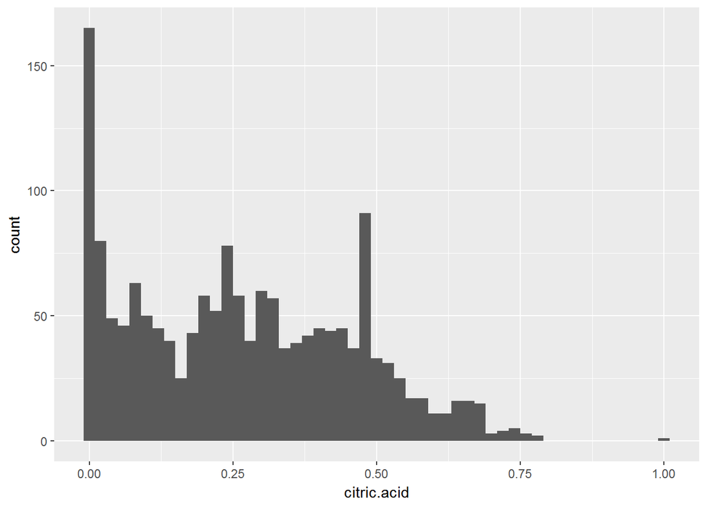

```
##    Min. 1st Qu.  Median    Mean 3rd Qu.    Max.
##   0.000   0.090   0.260   0.271   0.420   1.000
```

We see a positively skewed distribution with mean of 0.27 and max of 1

#### Chlorides (sodium chloride - g / dm^3)

chlorides: the amount of salt in the wine

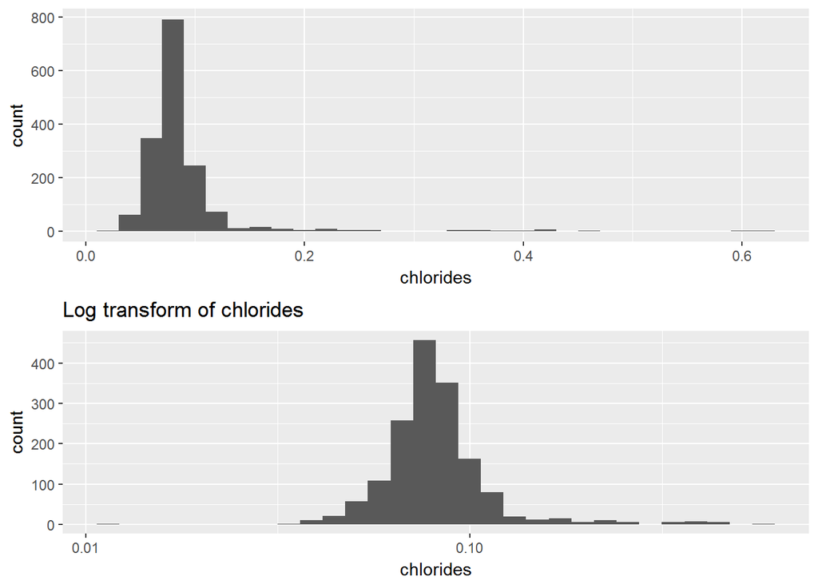

```
##    Min. 1st Qu.  Median    Mean 3rd Qu.    Max.
## 0.01200 0.07000 0.07900 0.08747 0.09000 0.61100
```

#### Free sulfur dioxide (mg / dm^3)

free sulfur dioxide: the free form of SO2 exists in equilibrium between molecular SO2 (as a dissolved gas) and bisulfite ion; it prevents microbial growth and the oxidation of wine

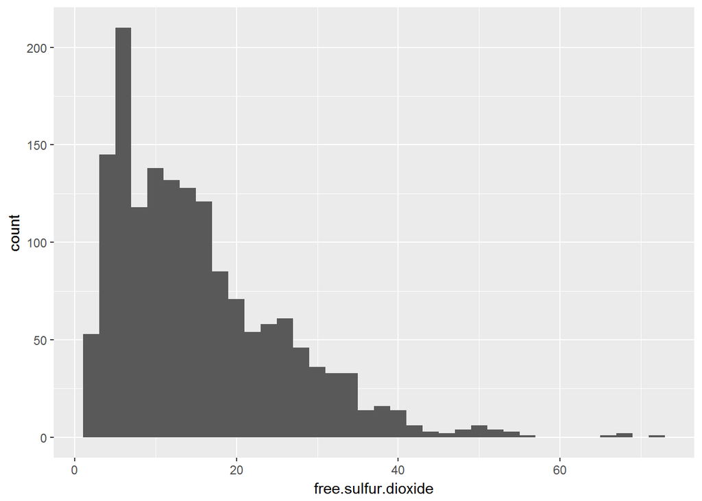

```
##    Min. 1st Qu.  Median    Mean 3rd Qu.    Max.
##    1.00    7.00   14.00   15.87   21.00   72.00
```

The distribution is positive skewed with mean of 15.87

#### Sulphates (potassium sulphate - g / dm3)

sulphates: a wine additive which can contribute to sulfur dioxide gas (S02) levels, wich acts as an antimicrobial and antioxidant

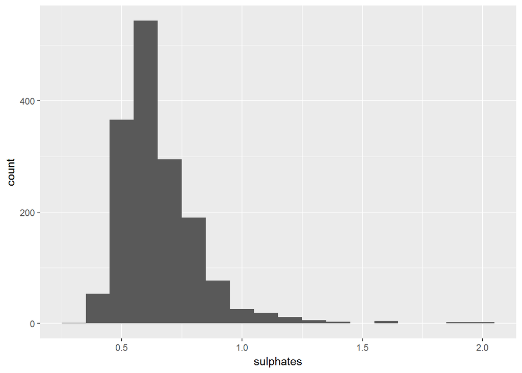

```
##    Min. 1st Qu.  Median    Mean 3rd Qu.    Max.
##  0.3300  0.5500  0.6200  0.6581  0.7300  2.0000
```

As expected from free sulfur dioxide graph this graph is also positive skewed with long tail.Mean is 0.65 and maximum of 2

#### Total sulfur dioxide (mg / dm^3)

total sulfur dioxide: amount of free and bound forms of S02; in low concentrations, SO2 is mostly undetectable in wine, but at free SO2 concentrations over 50 ppm, SO2 becomes evident in the nose and taste of wine

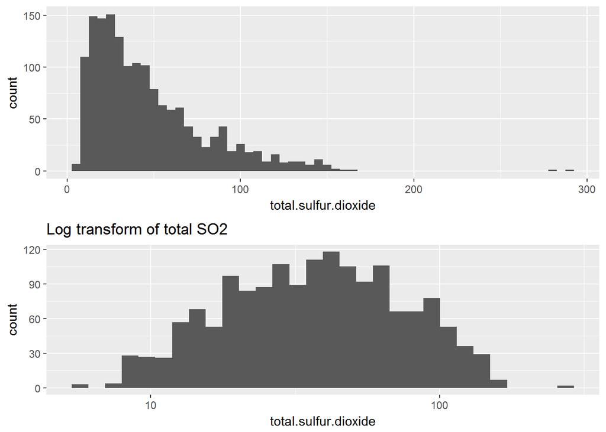

```
##    Min. 1st Qu.  Median    Mean 3rd Qu.    Max.
##    6.00   22.00   38.00   46.47   62.00  289.00
```

##### Summary of rating A wine

```
##  fixed.acidity    volatile.acidity  citric.acid     residual.sugar
##  Min.   : 4.900   Min.   :0.1200   Min.   :0.0000   Min.   :1.200
##  1st Qu.: 7.400   1st Qu.:0.3000   1st Qu.:0.3000   1st Qu.:2.000
##  Median : 8.700   Median :0.3700   Median :0.4000   Median :2.300
##  Mean   : 8.847   Mean   :0.4055   Mean   :0.3765   Mean   :2.709
##  3rd Qu.:10.100   3rd Qu.:0.4900   3rd Qu.:0.4900   3rd Qu.:2.700
##  Max.   :15.600   Max.   :0.9150   Max.   :0.7600   Max.   :8.900
##    chlorides       free.sulfur.dioxide total.sulfur.dioxide
##  Min.   :0.01200   Min.   : 3.00       Min.   :  7.00
##  1st Qu.:0.06200   1st Qu.: 6.00       1st Qu.: 17.00
##  Median :0.07300   Median :11.00       Median : 27.00
##  Mean   :0.07591   Mean   :13.98       Mean   : 34.89
##  3rd Qu.:0.08500   3rd Qu.:18.00       3rd Qu.: 43.00
##  Max.   :0.35800   Max.   :54.00       Max.   :289.00
##     density             pH          sulphates         alcohol
##  Min.   :0.9906   Min.   :2.880   Min.   :0.3900   Min.   : 9.20
##  1st Qu.:0.9947   1st Qu.:3.200   1st Qu.:0.6500   1st Qu.:10.80
##  Median :0.9957   Median :3.270   Median :0.7400   Median :11.60
##  Mean   :0.9960   Mean   :3.289   Mean   :0.7435   Mean   :11.52
##  3rd Qu.:0.9973   3rd Qu.:3.380   3rd Qu.:0.8200   3rd Qu.:12.20
##  Max.   :1.0032   Max.   :3.780   Max.   :1.3600   Max.   :14.00
##     quality      rating
##  Min.   :7.000   C:  0
##  1st Qu.:7.000   B:  0
##  Median :7.000   A:217
##  Mean   :7.083
##  3rd Qu.:7.000
##  Max.   :8.000
```

##### Summary of rating C wine

```
##  fixed.acidity    volatile.acidity  citric.acid     residual.sugar
##  Min.   : 4.600   Min.   :0.2300   Min.   :0.0000   Min.   : 1.200
##  1st Qu.: 6.800   1st Qu.:0.5650   1st Qu.:0.0200   1st Qu.: 1.900
##  Median : 7.500   Median :0.6800   Median :0.0800   Median : 2.100
##  Mean   : 7.871   Mean   :0.7242   Mean   :0.1737   Mean   : 2.685
##  3rd Qu.: 8.400   3rd Qu.:0.8825   3rd Qu.:0.2700   3rd Qu.: 2.950
##  Max.   :12.500   Max.   :1.5800   Max.   :1.0000   Max.   :12.900
##    chlorides       free.sulfur.dioxide total.sulfur.dioxide
##  Min.   :0.04500   Min.   : 3.00       Min.   :  7.00
##  1st Qu.:0.06850   1st Qu.: 5.00       1st Qu.: 13.50
##  Median :0.08000   Median : 9.00       Median : 26.00
##  Mean   :0.09573   Mean   :12.06       Mean   : 34.44
##  3rd Qu.:0.09450   3rd Qu.:15.50       3rd Qu.: 48.00
##  Max.   :0.61000   Max.   :41.00       Max.   :119.00
##     density             pH          sulphates         alcohol
##  Min.   :0.9934   Min.   :2.740   Min.   :0.3300   Min.   : 8.40
##  1st Qu.:0.9957   1st Qu.:3.300   1st Qu.:0.4950   1st Qu.: 9.60
##  Median :0.9966   Median :3.380   Median :0.5600   Median :10.00
##  Mean   :0.9967   Mean   :3.384   Mean   :0.5922   Mean   :10.22
##  3rd Qu.:0.9977   3rd Qu.:3.500   3rd Qu.:0.6000   3rd Qu.:11.00
##  Max.   :1.0010   Max.   :3.900   Max.   :2.0000   Max.   :13.10
##     quality      rating
##  Min.   :3.000   C:63
##  1st Qu.:4.000   B: 0
##  Median :4.000   A: 0
##  Mean   :3.841
##  3rd Qu.:4.000
##  Max.   :4.000
```

I am looking at the means of the distributions for identifying better variation between A and C rating wines. Some variations are in A—>B terms (percentage is taken over A)

Fixed.acidity - mean reduced by 11%

Volatile.acidity -mean increased by 80%

(This is just for estimation purposes and setting a way for further analysis.No final conclusion should be drawn from it)

# Univariate Analysis

### What is the structure of your dataset?

Dataset contains 1599 observations with 13 variable (14 is we count the the new ordered factor of rating).The data set is tidy.All values are float expect x and quality which are integer values

### What is/are the main feature(s) of interest in your dataset?

The main feature of interest in the dataset would be how alcohol concetrations effect the quality of red wine.I am also interested in looking at how pH varies in wines.

### What other features in the dataset do you think will help support your investigation into your feature(s) of interest?

I believe volatile acidity,citric acidity ,pH will also play a deep role . I also suspect that sulphates would have a positive impact on quality

### Did you create any new variables from existing variables in the dataset?

Yes i have created a variable rating which is a ordered factor of quality variable which is as follows 3 to 4 are C 5 to 6 are B 7 to 8 are A

### Of the features you investigated, were there any unusual distributions? Did you perform any operations on the data to tidy, adjust, or change the form of the data? If so, why did you do this?

No operations were needed to tidy the data, all observations were complete. Data appears to be wrangled There were some unusual distributions and outliers. The outliers seem to be true data values rather than input errors,although in some cases I have taken 99 and 95 qualtiles to make my graphsbetter

# Bivariate Plots Section

### Correlation among various variables

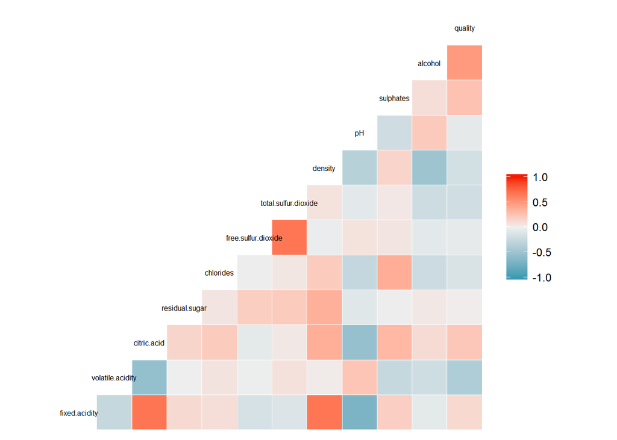

We can see the quality has a positive correlation with alcohol and citric acid and suplhates (as suspected in univarent) while it has a strong negative correlation with volatile acidity

### Volatile acidity vs Rating and quality

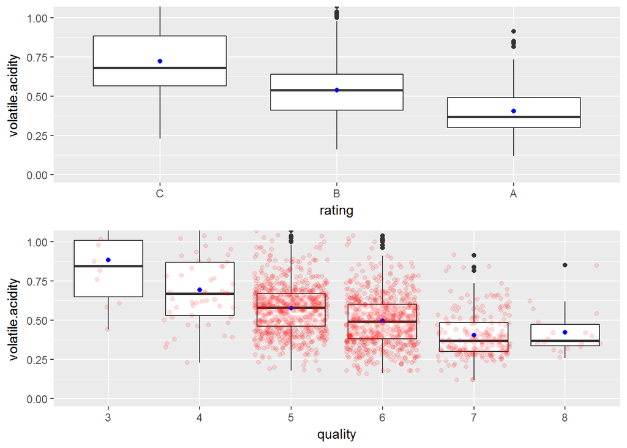

The box plots clearly shows how the volatile acidity decreases as the quality of wine improves.Well its not shocking who want to have a wine tasting like a ‘sour’ acid .The first boxplot shows the compares between our rating order pair the second one between the quality. The boxplot having quality also depicts the distribution of various wines and we can again see 5 and 6 quality wines have the most share.The blue dot is for the mean and the middle line shows the median

```
##
##  Pearson's product-moment correlation
##
## data:  rwine$volatile.acidity and rwine$quality
## t = -16.954, df = 1597, p-value < 2.2e-16
## alternative hypothesis: true correlation is not equal to 0
## 95 percent confidence interval:
##  -0.4313210 -0.3482032
## sample estimates:
##        cor
## -0.3905578
```

```
##
##  Kendall's rank correlation tau
##
## data:  rwine$volatile.acidity and rwine$quality
## z = -15.498, p-value < 2.2e-16
## alternative hypothesis: true tau is not equal to 0
## sample estimates:
##        tau
## -0.3007787
```

Both Pearson’s and kendall’s correlations are negative showing inverse trends like we figured out from the boxplots Further this high value of kendall’s rank correlation means high monotonic nature

### Quality vs Alcohol

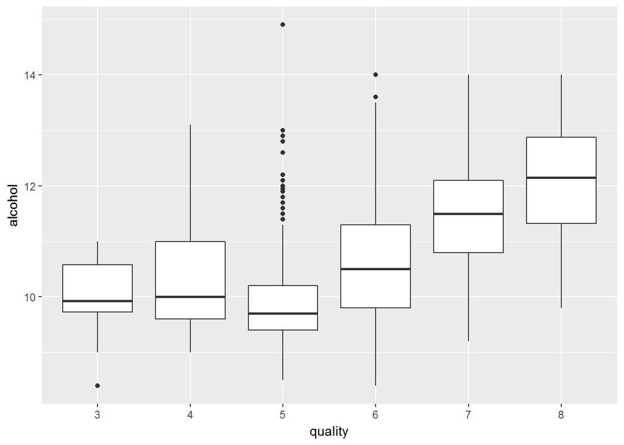

```
##
##  Pearson's product-moment correlation
##
## data:  rwine$alcohol and rwine$quality
## t = 21.639, df = 1597, p-value < 2.2e-16
## alternative hypothesis: true correlation is not equal to 0
## 95 percent confidence interval:
##  0.4373540 0.5132081
## sample estimates:
##       cor
## 0.4761663
```

##### So do if we keep on adding more alcohol will it give us a better wine?

Not necessarly, here is an example of how a more alcohol will ruin a top graded wine or have no effect on its quality

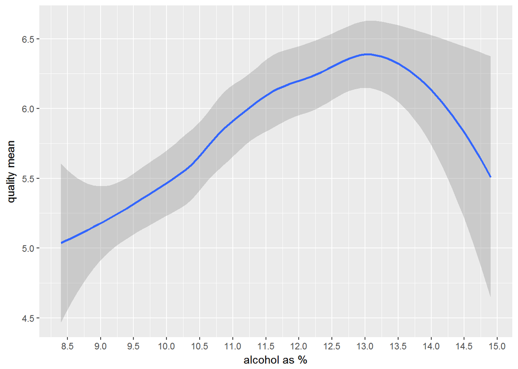

The above line plot indicates as sort of linear increase till 13% alcohol concetration, followed by a steep downwards trend. The graph has be smoothed to remove variances and noise.

```
##
##  Pearson's product-moment correlation
##
## data:  above13$quality and above13$alcohol
## t = -0.39861, df = 21, p-value = 0.6942
## alternative hypothesis: true correlation is not equal to 0
## 95 percent confidence interval:
##  -0.4816540  0.3376049
## sample estimates:
##         cor
## -0.08665653
```

It interesting to see that the correlation between alcohol and quality diminishes and even becomes negative(reciprocal effect) when we approach above the 13% alcohol by volume mark

### Quality vs citric acid

```
##
##  Pearson's product-moment correlation
##
## data:  rwine$citric.acid and rwine$quality
## t = 9.2875, df = 1597, p-value < 2.2e-16
## alternative hypothesis: true correlation is not equal to 0
## 95 percent confidence interval:
##  0.1793415 0.2723711
## sample estimates:
##       cor
## 0.2263725
```

The correlation between citric acid and quality is 0.226 though being a weak correlation it do effect the quality of wine

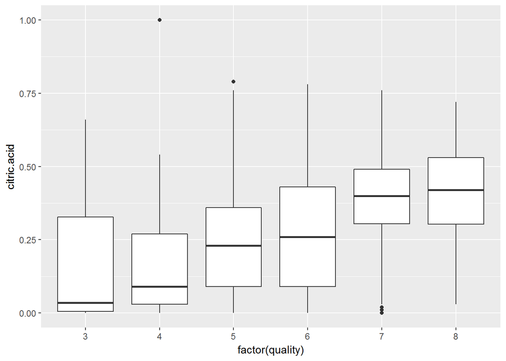

The boxplots shows how the citric acid median values shows a steady increase as we move to better quality wines

### Quality vs Suplhates

```
##
##  Pearson's product-moment correlation
##
## data:  rwine$sulphates and rwine$quality
## t = 10.38, df = 1597, p-value < 2.2e-16
## alternative hypothesis: true correlation is not equal to 0
## 95 percent confidence interval:
##  0.2049011 0.2967610
## sample estimates:
##       cor
## 0.2513971
```

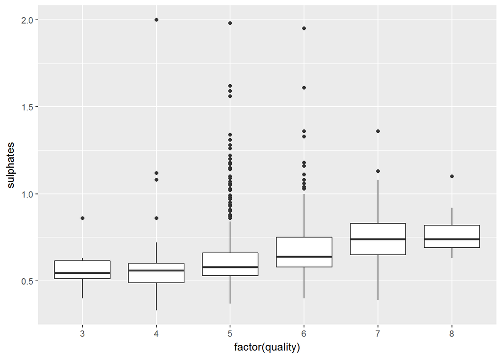

Good wines have higher sulphates values than bad wines, though the difference is not that wide. The correlation between these two variables is 0.251

#### Veiw of Quality through density plots

Density plots are an interesting way of visulisation ,I have provided them for some variables in relation with quality

##### For alcohol

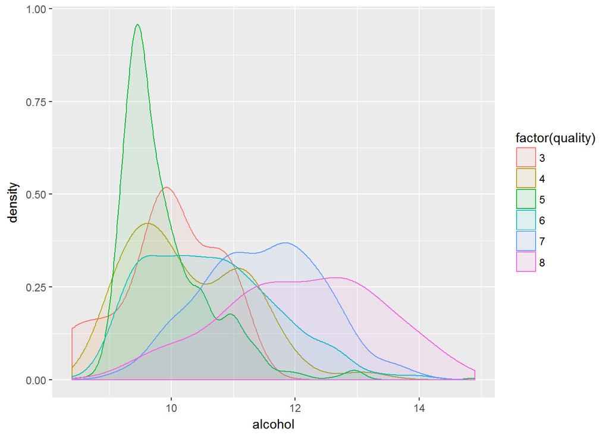

##### For volatile acidity

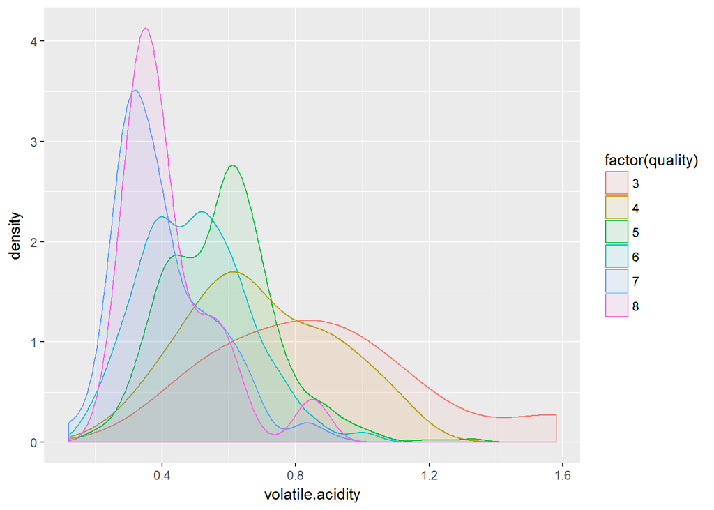

Redwine of quality 7 and 8 have their peaks for volatile acidity well below the 0.4 mark.Wine with quality 3 has the pick at the most right handside (towards more volatile acidity)

##### For sulphates

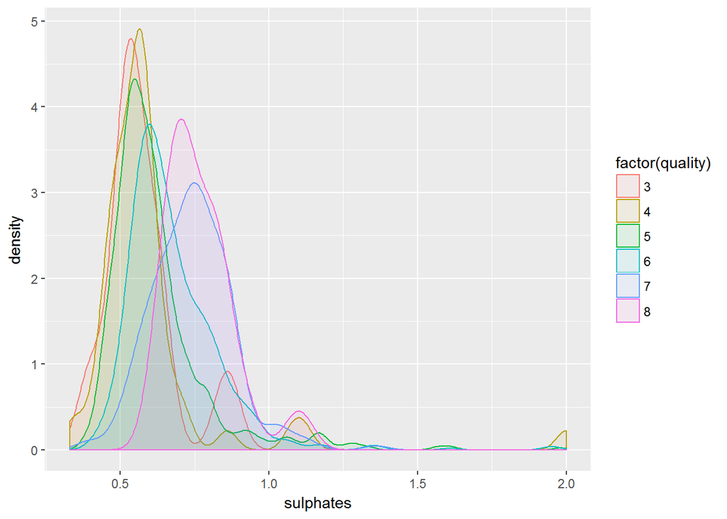

Nearly all wines are below 1.0 marks.We see a sideward movement of peaks towards more sulphate side as we increase the quality .This was also observered with alcohol

##### For citric acid

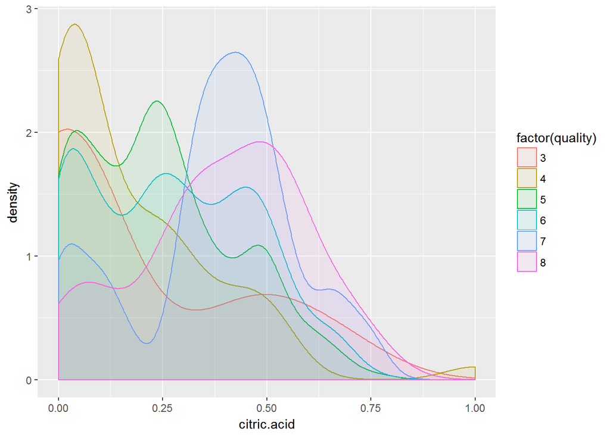

7 and 8 quality wine appear to be clear winners here .Citric acid had a positive correlation with quality which is depicted well by density plots

### Fixed acidity and citric acid relation with pH

Both acidity should have a correlation with pH as pH scales is made for acids and bases

```
##
##  Pearson's product-moment correlation
##
## data:  rwine$pH and rwine$citric.acid
## t = -25.767, df = 1597, p-value < 2.2e-16
## alternative hypothesis: true correlation is not equal to 0
## 95 percent confidence interval:
##  -0.5756337 -0.5063336
## sample estimates:
##        cor
## -0.5419041
```

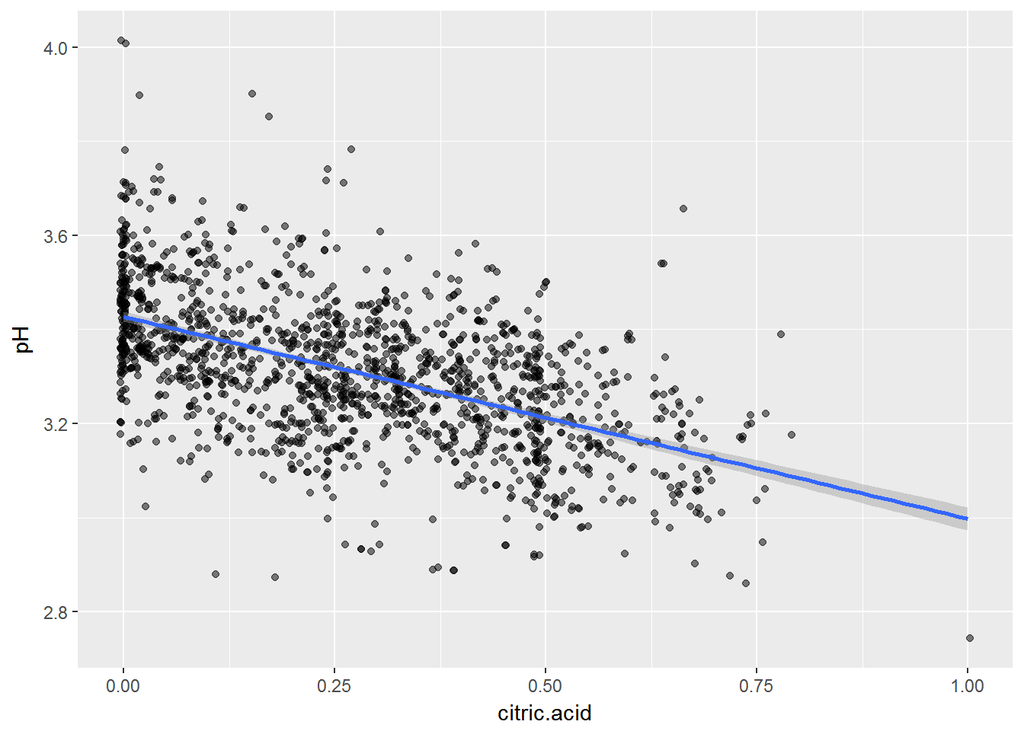

Well negative correlation and the scatter plot shows how the citric acid increment lowers pH

```
##
##  Pearson's product-moment correlation
##
## data:  rwine$fixed.acidity and rwine$pH
## t = -37.366, df = 1597, p-value < 2.2e-16
## alternative hypothesis: true correlation is not equal to 0
## 95 percent confidence interval:
##  -0.7082857 -0.6559174
## sample estimates:
##        cor
## -0.6829782
```

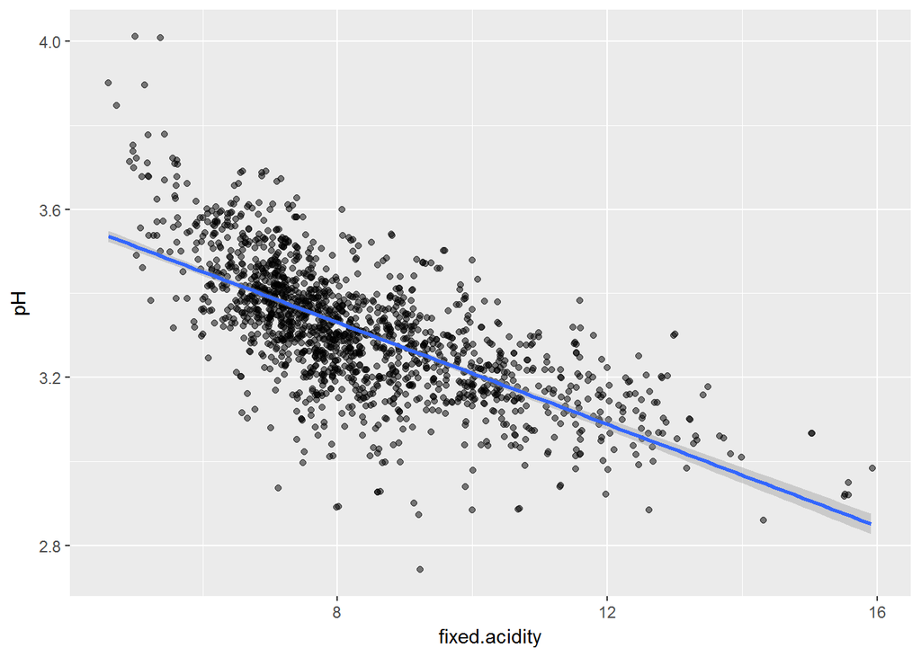

Same is for fixed acidity the correlation is at wooping -0.68

### Free sulfur dioxide vs total sulfur dioxide

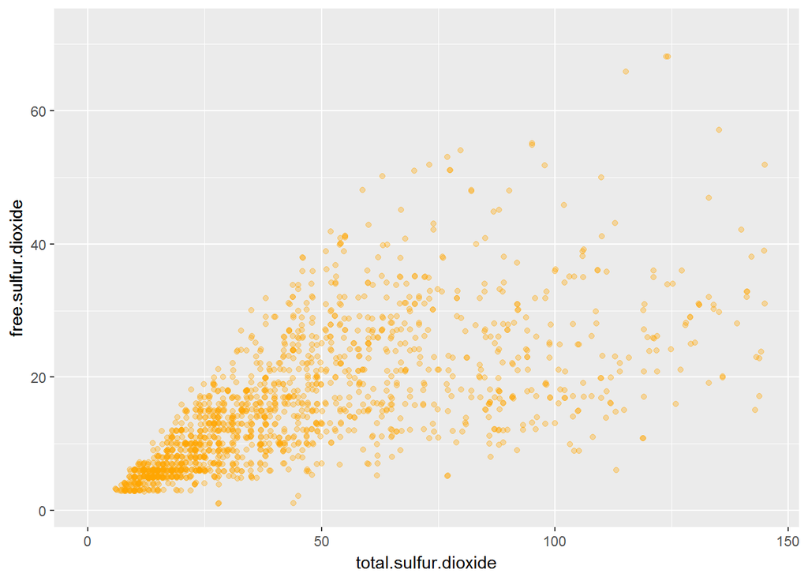

A scatter plot between total sulfur dioxide and free sulfur dioxide.shows that the both entities are related. The following scatter plot doesnot shows a linear trend but shows a conical arrangement

```
##
##  Pearson's product-moment correlation
##
## data:  rwine$free.sulfur.dioxide and rwine$total.sulfur.dioxide
## t = 35.84, df = 1597, p-value < 2.2e-16
## alternative hypothesis: true correlation is not equal to 0
## 95 percent confidence interval:
##  0.6395786 0.6939740
## sample estimates:
##       cor
## 0.6676665
```

The correlation between the two explains the scatterplot further.In most cases correlation does not implies causation but in this case the increase in total sulphur dioxide is causing increase in free sulphur dioxide due to its decay

# Bivariate Analysis

### Talk about some of the relationships you observed in this part of the investigation. How did the feature(s) of interest vary with other features in the dataset?

My main analysis was regarding quality these are some of the relationsips i observed

##### Alcohol

Below 13 % - Alcohol has a positive correlation of 0.47 the heighest correlation on positive side with quality of red wine.The boxplots also show an increase in median alcohol % with increase in quality

above 13% - Trends seem to be different as we epproach above 13% mark.The correlation diminish rather become negative

##### Volatile acidity

Volatile acidity had a pearson’s R of -0.39 and kendall’s tau of -0.30 which shows the inverse relation between quality and volatile acidity.Volatile acidity Even the boxplots showed the median for each increase in quality has a lower value of volatile acidity

##### Citric acid

Citric acid showed an positive correlation of 0.22 and the boxplots depicted a rise in its concentrations from low quality wines to high quality onces.It incresting to note that the values of citric acid for a quality lying in same rating group had nearly same concetrations .i.e the concentration of 3-4 were nearly same.A exponetial rise in citric acid came then we moved from C rating wine to B rating one or B rating one to A rating one

##### Sulphates

Fixed acidity and citric acid relation with pH was also observed .Though results were not that surprising

### Did you observe any interesting relationships between the other features (not the main feature(s) of interest)?

Yup i found the relationship between free sulfur dioxide and total sulfurdioxide which were not main part of my research also high correlation between density and fixed acidity was observed

### What was the strongest relationship you found?

I found the strongest relation between pH and fixed acidity at wooping -0.68.I was expecting it,The second strongest trend was between totalsulfurdioxide and free sulphur dioxide.

For quality analysis of red wine i found that alcohol and volatile acidity had the strongest relationship

# Multivariate Plots Section

### Alcohol and citric Acid

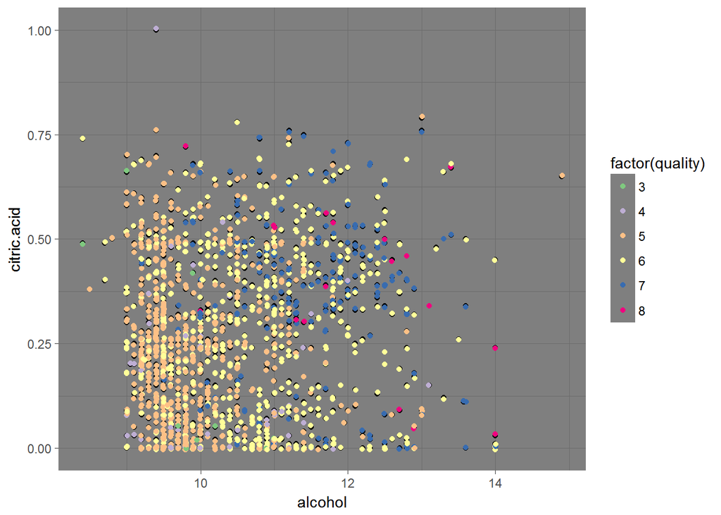

### Alcohol and Volatile acidity

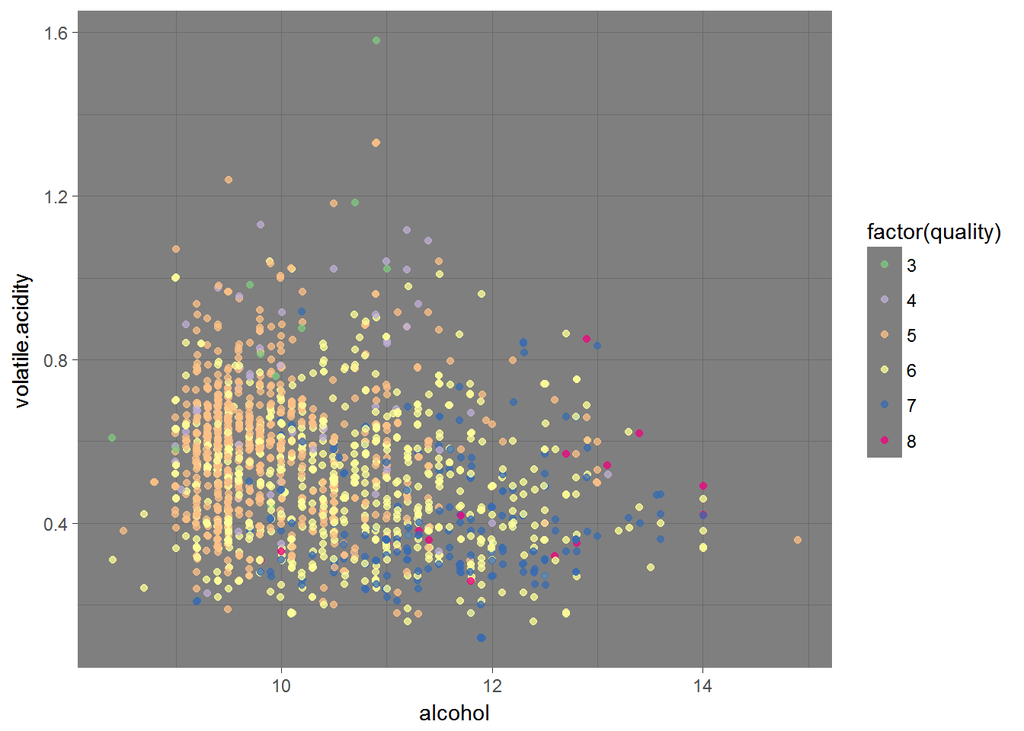

Even though the volatile acidity and alcohol had high correlations values of negative and positive.Alcohol seems to vary more than volatile acidity when we talk about quality,nearly every Rating A wine has less than 0.6 volatile acidity.Well I thinks its acceptable as volatile acid is acetic acid, no one wants their redwine to taste like vinegar

#### Lets talk acid!

volatile acidity has negative corelation while citric acidity has a positive one I was interested in seeing how they related with each other

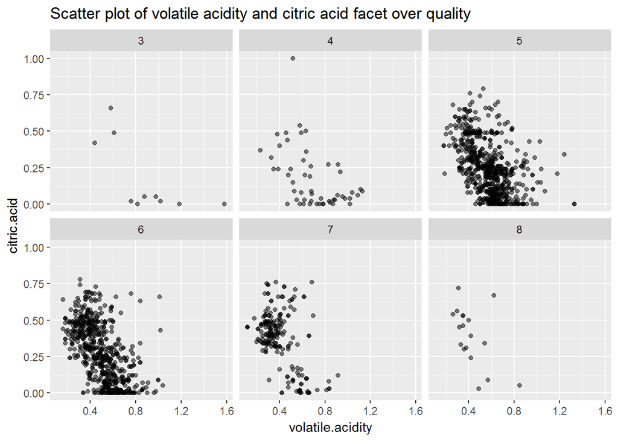

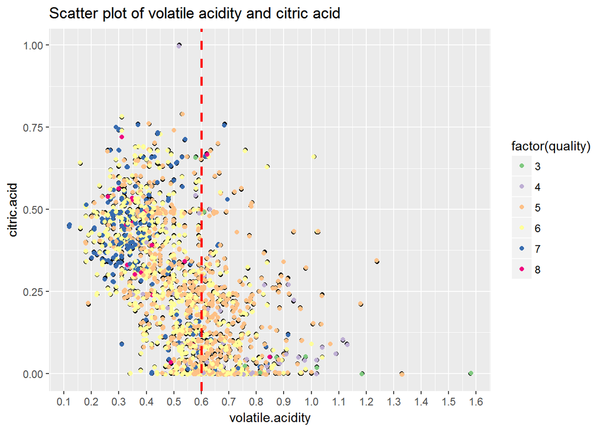

Most A rating wines (quality 7-8) have citric acid value of 0.25 to 0.75 ,While the B rating wines(quality 6-5) have citric acid value below 0.50